# Wine data exploration by Stephan Ketterer

```r
summary(data)
```

```
##        X        fixed.acidity    volatile.acidity  citric.acid
##  Min.   :   1   Min.   : 3.800   Min.   :0.0800   Min.   :0.0000
##  1st Qu.:1225   1st Qu.: 6.300   1st Qu.:0.2100   1st Qu.:0.2700
##  Median :2450   Median : 6.800   Median :0.2600   Median :0.3200
##  Mean   :2450   Mean   : 6.855   Mean   :0.2782   Mean   :0.3342
##  3rd Qu.:3674   3rd Qu.: 7.300   3rd Qu.:0.3200   3rd Qu.:0.3900
##  Max.   :4898   Max.   :14.200   Max.   :1.1000   Max.   :1.6600
##  residual.sugar     chlorides       free.sulfur.dioxide
##  Min.   : 0.600   Min.   :0.00900   Min.   :  2.00
##  1st Qu.: 1.700   1st Qu.:0.03600   1st Qu.: 23.00
##  Median : 5.200   Median :0.04300   Median : 34.00
##  Mean   : 6.391   Mean   :0.04577   Mean   : 35.31
##  3rd Qu.: 9.900   3rd Qu.:0.05000   3rd Qu.: 46.00
##  Max.   :65.800   Max.   :0.34600   Max.   :289.00
##  total.sulfur.dioxide    density             pH          sulphates
##  Min.   :  9.0        Min.   :0.9871   Min.   :2.720   Min.   :0.2200
##  1st Qu.:108.0        1st Qu.:0.9917   1st Qu.:3.090   1st Qu.:0.4100
##  Median :134.0        Median :0.9937   Median :3.180   Median :0.4700
##  Mean   :138.4        Mean   :0.9940   Mean   :3.188   Mean   :0.4898
##  3rd Qu.:167.0        3rd Qu.:0.9961   3rd Qu.:3.280   3rd Qu.:0.5500
##  Max.   :440.0        Max.   :1.0390   Max.   :3.820   Max.   :1.0800
##     alcohol         quality
##  Min.   : 8.00   Min.   :3.000
##  1st Qu.: 9.50   1st Qu.:5.000
##  Median :10.40   Median :6.000
##  Mean   :10.51   Mean   :5.878
##  3rd Qu.:11.40   3rd Qu.:6.000
##  Max.   :14.20   Max.   :9.000
```

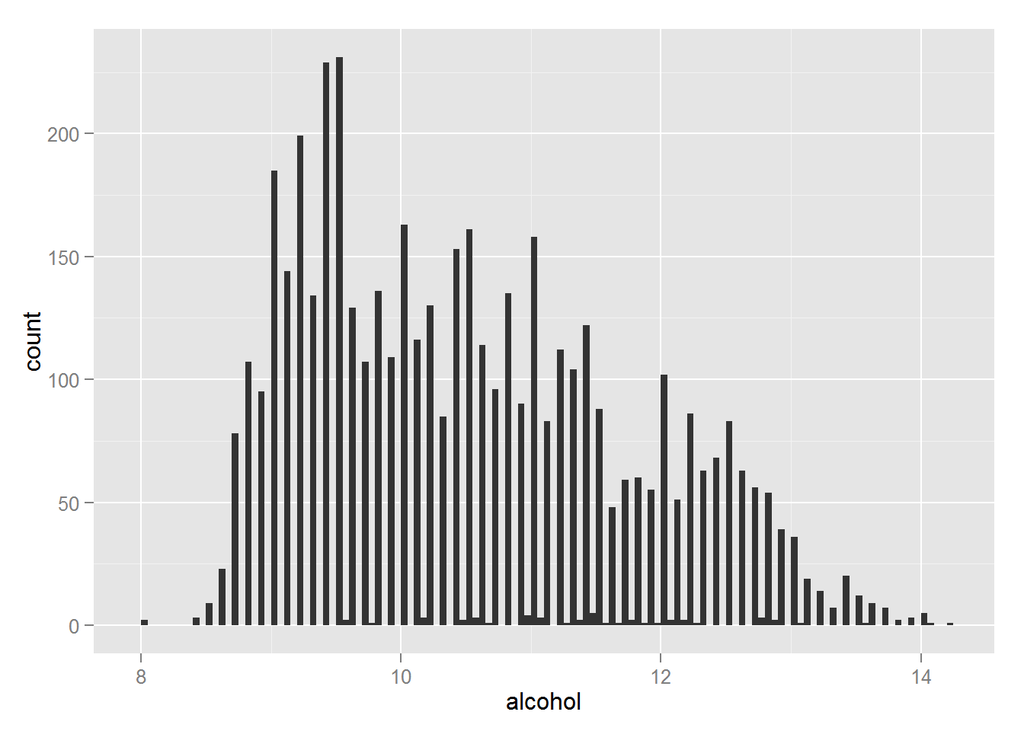

Overall we are interested in the taste( the quality variable) i wanna see how sugar is distributed in the different wines.

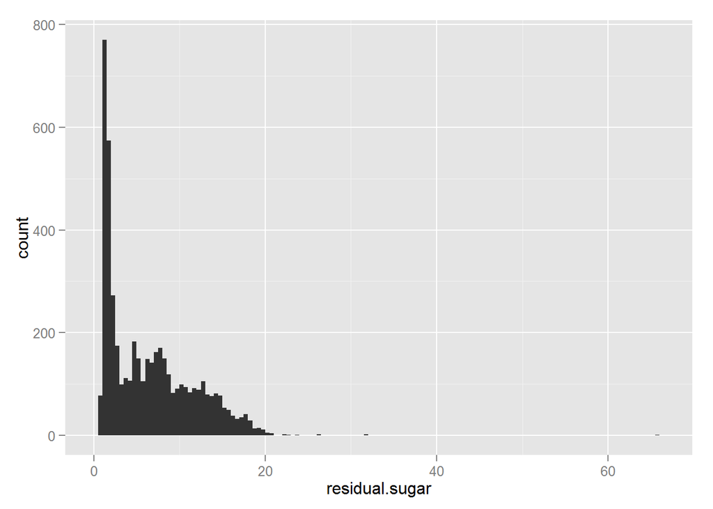

Clearly not a bell shaped distribution and the x- axis should be formatted to allow a better overview.

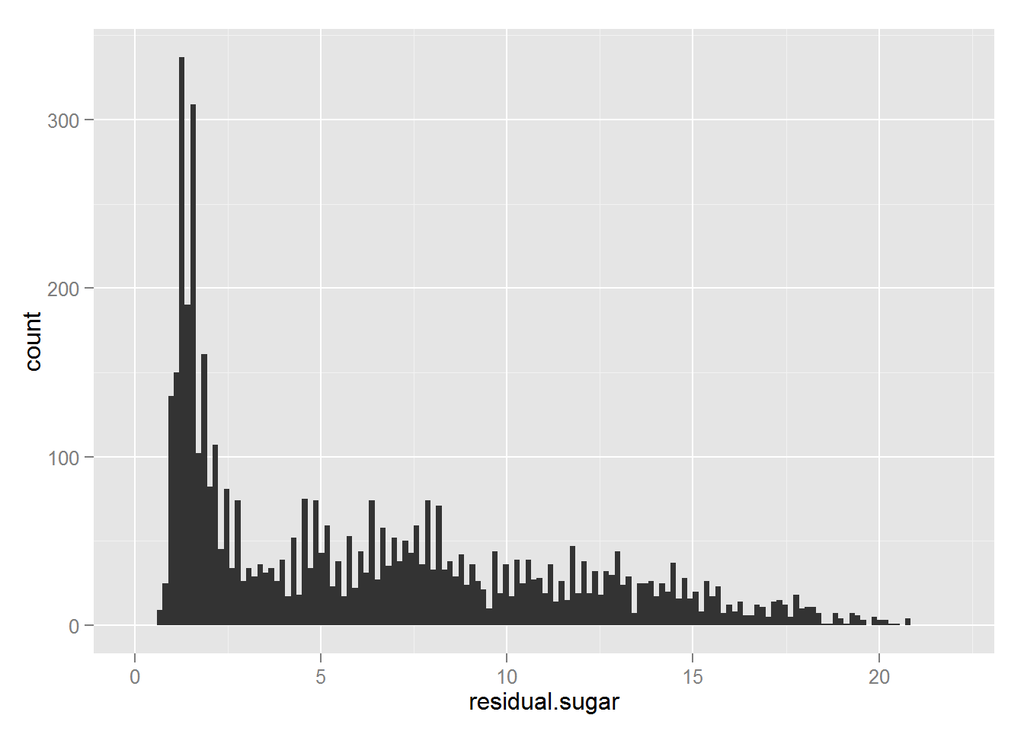

A lot better use of the given space that increases the visibilty of the results.

Finally let us have a look of quality is distributed, since after all that is the variable we are most interested in.

```
## data$quality
##       n missing  unique    Info    Mean
##    4898       0       7    0.88   5.878
##
##            3   4    5    6   7   8 9
## Frequency 20 163 1457 2198 880 175 5
## %          0   3   30   45  18   4 0
```

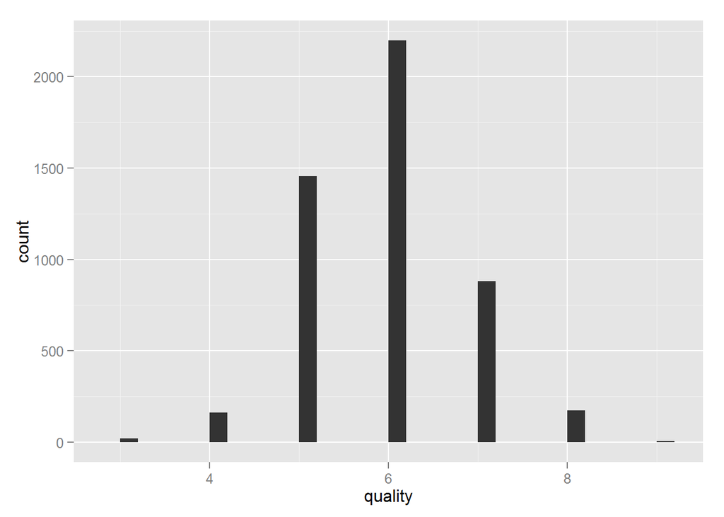

We can observe what looks pretty much like a bell curve, with a median of 6. Noticable is that we dont have any ten in our scores, or scores lower than 3.If look back at the summary at the start of the analysis, we can see that the Median is in infact 6 and the Mean with 5.878 is very close to it.

Just for good measure, i wanna look at a variable that is not self explanatory and i actually had to look up.

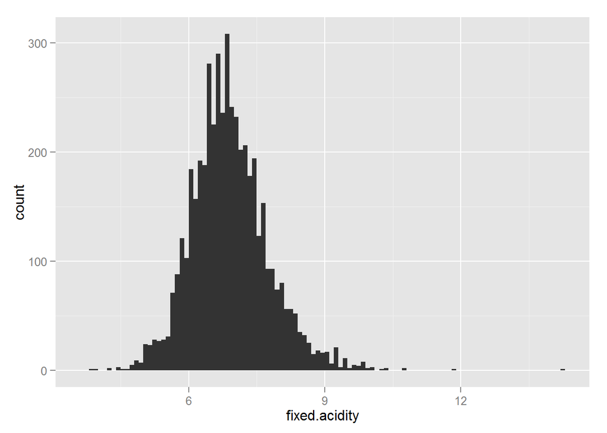

# Univariate Analysis

### What is the structure of your dataset?

There are 4898 wines in the dataset with 12 features (fixed acidity, volatile acidity, citric acid, residual sugar, chlorides, free sulfur dioxide, total sulfur dioxide, density, pH, sulphates,alcohol and quality ).

### What is/are the main feature(s) of interest in your dataset?

The main features in the data set is quality. I’d like to determine which features are best for predicting the quality of the wine. Since i am not much of a drinker, i have hardly any experience with wine. That means i have no preconceived notion which variables will be more important to the quality of the wine over others. However i have a hunch that the amount of residual sugar might play an important role, since sugar influences the taste so much.

### What other features in the dataset do you think will help support your investigation into your feature(s) of interest?

I think all the acid variables will be of interest, since again, the level of acidity has a big impact on the taste.

### Of the features you investigated, were there any unusual distributions? Did you perform any operations on the data to tidy, adjust, or change the form of the data? If so, why did you do this?

# Bivariate Plots Section

```
##                                 X fixed.acidity volatile.acidity
## X                     1.000000000   -0.25581431      0.002857966
## fixed.acidity        -0.255814305    1.00000000     -0.022697290
## volatile.acidity      0.002857966   -0.02269729      1.000000000
## citric.acid          -0.149899918    0.28918070     -0.149471811
## residual.sugar        0.006623775    0.08902070      0.064286060
## chlorides            -0.045645192    0.02308564      0.070511571
## free.sulfur.dioxide  -0.011928911   -0.04939586     -0.097011939
## total.sulfur.dioxide -0.161979037    0.09106976      0.089260504
## density              -0.185976097    0.26533101      0.027113845
## pH                   -0.115774132   -0.42585829     -0.031915368
## sulphates             0.009807759   -0.01714299     -0.035728147
## alcohol               0.213656245   -0.12088112      0.067717943
## quality               0.035763247   -0.11366283     -0.194722969
##                       citric.acid residual.sugar   chlorides
## X                    -0.149899918    0.006623775 -0.04564519
## fixed.acidity         0.289180698    0.089020701  0.02308564
## volatile.acidity     -0.149471811    0.064286060  0.07051157
## citric.acid           1.000000000    0.094211624  0.11436445
## residual.sugar        0.094211624    1.000000000  0.08868454
## chlorides             0.114364448    0.088684536  1.00000000
## free.sulfur.dioxide   0.094077221    0.299098354  0.10139235
## total.sulfur.dioxide  0.121130798    0.401439311  0.19891030
## density               0.149502571    0.838966455  0.25721132
## pH                   -0.163748211   -0.194133454 -0.09043946
## sulphates             0.062330940   -0.026664366  0.01676288
## alcohol              -0.075728730   -0.450631222 -0.36018871
## quality              -0.009209091   -0.097576829 -0.20993441
##                      free.sulfur.dioxide total.sulfur.dioxide     density
## X                          -0.0119289106         -0.161979037 -0.18597610
## fixed.acidity              -0.0493958591          0.091069756  0.26533101
## volatile.acidity           -0.0970119393          0.089260504  0.02711385
## citric.acid                 0.0940772210          0.121130798  0.14950257
## residual.sugar              0.2990983537          0.401439311  0.83896645
## chlorides                   0.1013923521          0.198910300  0.25721132
## free.sulfur.dioxide         1.0000000000          0.615500965  0.29421041
## total.sulfur.dioxide        0.6155009650          1.000000000  0.52988132
## density                     0.2942104109          0.529881324  1.00000000
## pH                         -0.0006177961          0.002320972 -0.09359149
## sulphates                   0.0592172458          0.134562367  0.07449315
## alcohol                    -0.2501039415         -0.448892102 -0.78013762
## quality                     0.0081580671         -0.174737218 -0.30712331
##                                 pH    sulphates     alcohol      quality
## X                    -0.1157741316  0.009807759  0.21365624  0.035763247
## fixed.acidity        -0.4258582910 -0.017142985 -0.12088112 -0.113662831
## volatile.acidity     -0.0319153683 -0.035728147  0.06771794 -0.194722969
## citric.acid          -0.1637482114  0.062330940 -0.07572873 -0.009209091
## residual.sugar       -0.1941334540 -0.026664366 -0.45063122 -0.097576829
## chlorides            -0.0904394560  0.016762884 -0.36018871 -0.209934411
## free.sulfur.dioxide  -0.0006177961  0.059217246 -0.25010394  0.008158067
## total.sulfur.dioxide  0.0023209718  0.134562367 -0.44889210 -0.174737218
## density              -0.0935914935  0.074493149 -0.78013762 -0.307123313
## pH                    1.0000000000  0.155951497  0.12143210  0.099427246
## sulphates             0.1559514973  1.000000000 -0.01743277  0.053677877
## alcohol               0.1214320987 -0.017432772  1.00000000  0.435574715
## quality               0.0994272457  0.053677877  0.43557472  1.000000000
```

When analysing two variables a good first step is to get the correlations of all possible combinations of variables.That way we get a good overview of how variables relate to each other and what pairs might be interesting for further investigation.

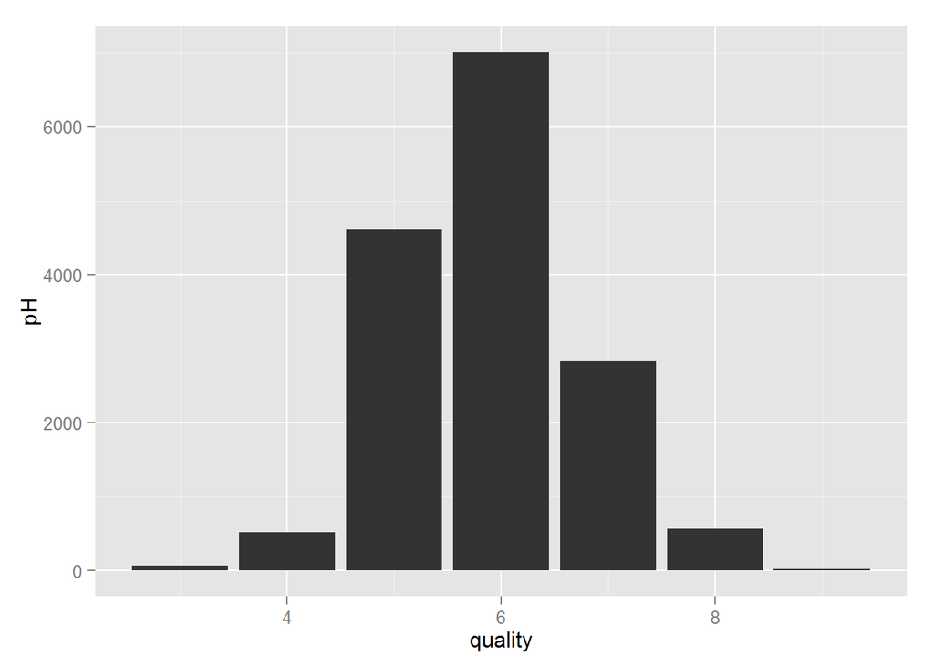

As a test, quality to pH. As the correlation factor would suggest, not much knowledge to gain here.

# Bivariate Analysis

### Did you observe any interesting relationships between the other features (not the main feature(s) of interest)?

The strongest relationships between two variables occured both in relation to densitiy. The correlation factor between density and residual sugar is 0.84, and between densitiy and alcohol -0.78. Both numbers indicate a very strong correlation. Those numbers are not at all suprising, since both sugar, and Alcohol( Chemically Ethanol) have different densities than water, which leads to the overall different densities of the different wines.

### What was the strongest relationship you found?

density and residual sugar have a correlation coefficent of +0.84.

# Multivariate Plots Section

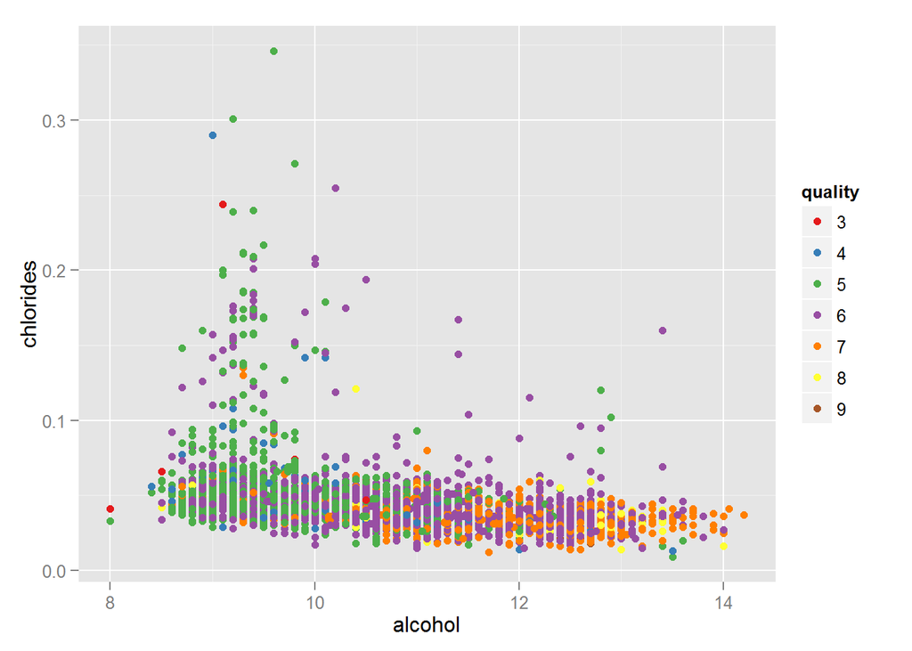

We start with the quality with respect to level of alcohol and chloride level. We can clearly observe that the majoriy of datapoints are at the bottom at the graph. Still i am reluctant to just transform the axis to blow this part up. There are too many outliers with higher chloride levels in my judgement to simply cut them all off. Still we can clearly see the correlation of higher level of alcohol and higher quality grading.

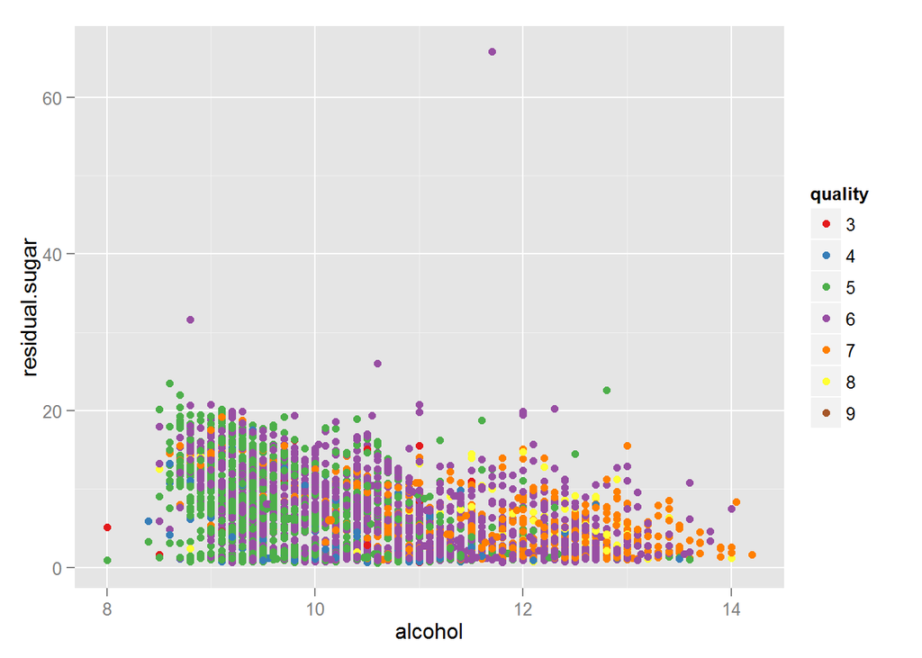

This plot shows a lot less outliers and at a later point in the analysis we will use it again later with transformed axis for a better overview of the data.

View(data)

What is clear by this point is, that with linear correlations over the entire range of the variables, we will not figure out what makes a wine get a good quality grading. Besides alcohol level the correlations are very weak. If i want to find meaningful conclusions from the dataset, i have to think about things that might evade the strict correlations calculation. I came up with the idea of “islands” of good quality wines. Where the conditions of the variables are just at the right levels to each other to get a good wine. These islands (if they exist at all) would not be detected by the classic correlation value. So went to stackoverflow made a post about my thinking, only to find out that what i naively called “islands” is actually knwon under the term “clustering”. So i watched a video about k-means clustering and just thought i give it a try.

data2<-data

I thought i will chose 3 is the number of different clusters so i can make the results easier to interpet.

```
## K-means clustering with 3 clusters of sizes 1633, 1633, 1632
##
## Cluster means:
##        X fixed.acidity volatile.acidity citric.acid residual.sugar
## 1 2450.0      7.013625        0.2724189   0.3324801       6.668769
## 2  817.0      7.023699        0.2800153   0.3653399       6.031843
## 3 4082.5      6.526838        0.2822917   0.3047365       6.473683
##    chlorides free.sulfur.dioxide total.sulfur.dioxide   density       pH
## 1 0.04560992            35.85119             142.1332 0.9944441 3.196399
## 2 0.04644519            34.84691             143.5582 0.9943802 3.206160
## 3 0.04526164            35.22610             129.3851 0.9932574 3.162224
##   sulphates  alcohol
## 1 0.4924923 10.40998
## 2 0.4861298 10.29124
## 3 0.4909191 10.84178
```

[output cut: 157 more lines]

```
##
##       1   2   3
##   3   6  10   4
##   4  59  65  39
##   5 549 486 422
##   6 686 697 815
##   7 276 302 302
##   8  57  68  50
##   9   0   5   0
```

Unfortunately even a quick glance shows us that the clustering( atleast in that way)did not work at all. Almost any grade is equally distributed over the calculated 3 clusters. Which means we cannot deduct any new knowledge from the clustering.

Just to make sure we did not overlook something, let’s plot those 3 buckets.

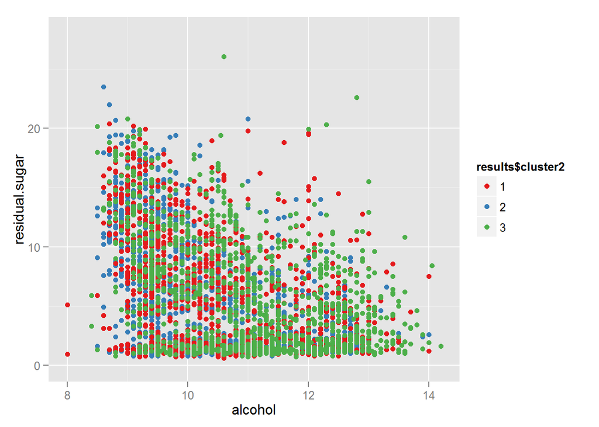

I transformed the axis to get rid of a few outliers. But just as we suspected from the numbers, the colors(buckets) are spread out all over the graph. There is no observerable concentration of any color in any part of the graph. Therefore our attempt to cluster the dataset to gain more insight into what makes a good wine failed.

# Multivariate Analysis

### Talk about some of the relationships you observed in this part of the investigation. Were there features that strengthened each other in terms of looking at your feature(s) of interest?

Since the variable we are interested is quality, and the bivariate analysis showed the strongest correlation with alcohol content, i figured it is a good starting point to keep those two variables in the analysis and add one other.In order to use quality for those plots, i had to factor it . The only thing rather interesting was the almost utter lack of correlation between the value of interest(quality) and the other variables.

### Were there any interesting or surprising interactions between features?

When looking at quality and alcohol level specificially with the added variable of residual sugar,i fount it interesting, that there were several outliers with much higher residual sugar content.I discarded them in later plots to spread the remaining points better over the entire plot, but still it made me wonder, because all the outliers seemed to have decent quality grading.

### OPTIONAL: Did you create any models with your dataset? Discuss the strengths and limitations of your model.

# Final Plots and Summary

### Plot One

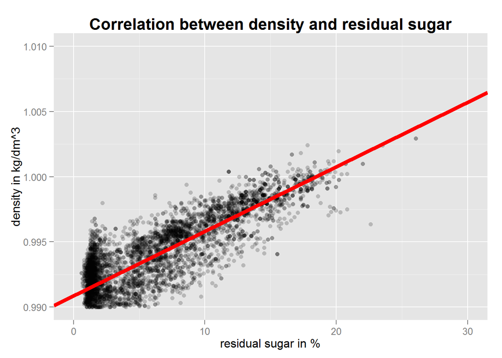

```
##    (Intercept) residual.sugar
##   0.9908653878   0.0004947244
```

### Plot Two

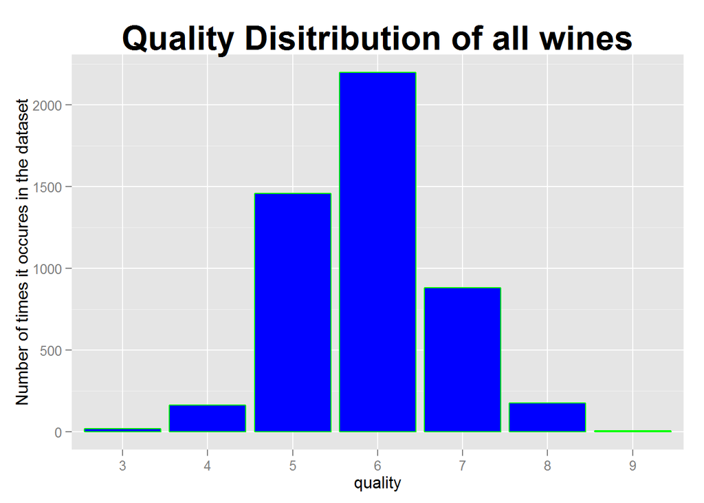

### Description Two

The graph demonstrates the highly subjective quality assessment. There are no wines given the top score of 10, but also no wines that receive a score lower than 3. Given a dataset with almost 5000 wines that seems highly unlikely if it were not graded by humans.

### Plot Three

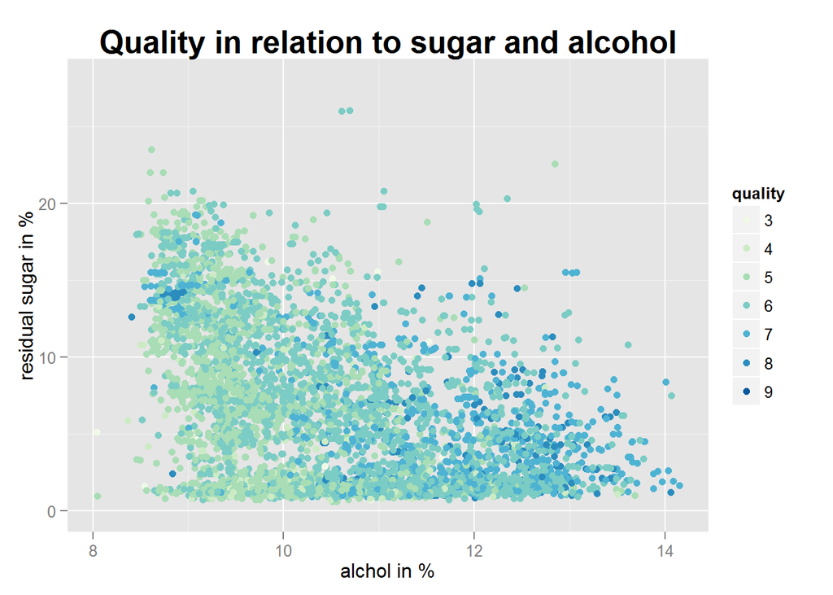

### Description Three

Jitter on the x-axis added was added to make the graph a bit more realistic. Very discrete values don’t seem to model the real world very well in that instance, so with jitter we get a better understanding in my oppinion. We cleary see that on average , with more alcohol the quality grading is higher, but that the residual sugar has almost no effect.

# Reflection

The wine dataset contained almost 5000 different kinds of white wines. I started out analyzing the data by looking over every pssible combination of correlation.Unfortunately the strongest ones, the direct correlation between density and residual sugar and density and level of alcohol were not containing the quality attributed to the wine, which was the variable of interest in that dataset.Those two strong correlations can be easily explained by simple physical properties(Ethanol is simply “lighter” than water and therefore lowers the overall density of the wine).Looking specifically at the quality grading of the wines, at first sight, the dataset seemed rather disappointing. Just one useful correlations, qquality and level of alcohol. The higher the level of alcohol the better the quality grading on average. That is disappointing, since it gives little guidance concerning all other variables how to produce a wine that can be expected to be graded highly.On second glance though this result was almost expectable in my oppinion. First of all , the quality grading is done by humans, and complety subjective. This is easily illustrated by the fact, that eventhough the rating system goes from one to ten, the highest grade was a 9, and there was no grade lower than a 3. Given a sample size of 5000, that is statistically just very unlikely in an objectively asssed variable. Finally, and the most important point in my oppinion is the following. If it was possible to predict with certainty the grading of a wine , and therefore extract the conditions of those ten variables under which a very high grading is achieved, there would be no more bad graded wines on the market within a very short period of time. Winemakers would simply analyze their product and adjust those characteristics to values that would assure a high grading. Therefore my final conclusion is, that the topic of “subjective taste” of wine might simple not be a good candidate for data analysis, atleast when only looking at the ten variables that were included in the dataset.